# TOGroupProject2

Wendy Liu, Mack Khoo, Nelvin Vincent, TJ Striblen, & Nihal Kurki

2022-10-27

## Problem

Dataset from: https://www.kaggle.com/datasets/sakshigoyal7/credit-card-customers This dataset consists of 10,000 customers mentioning their age, salary, marital_status, credit card limit, credit card category, etc.(nearly 18 features). The dataset only consists of 16.07% of customers who have churned.

Business Problem: A business manager of a consumer credit card bank is facing the problem of customer attrition. They want to analyze the data to find out the reason behind this and leverage the same to predict customers who are likely to drop off. They also want to predict customer churn from the dataset and gain some insights on how the bank can reduce the customers who have churned.

Our group wants to predict which credit card customers are more likely to churn. Churn prediction means detecting which customers are likely to leave a service or to cancel a subscription to a service. It is a critical prediction for many businesses because acquiring new clients often costs more than retaining existing ones.

## Data Exploration

### Downloading and Cleaning the Data

```r
credit <- read.csv("BankChurners.csv", stringsAsFactors = TRUE)

credit$CLIENTNUM <- NULL
credit$Naive_Bayes_Classifier_Attrition_Flag_Card_Category_Contacts_Count_12_mon_Dependent_count_Education_Level_Months_Inactive_12_mon_1 <- NULL
credit$Naive_Bayes_Classifier_Attrition_Flag_Card_Category_Contacts_Count_12_mon_Dependent_count_Education_Level_Months_Inactive_12_mon_2 <- NULL

# Ordinal variable
credit$Income_Category <- factor(credit$Income_Category, levels = c("Less than $40K", "$40K - $60K", "$60K - $80K", "$80K - $120K", "$120K +", "Unknown"), labels = c(0, 1, 2, 3, 4, 5))

credit$Card_Category <- factor(credit$Card_Category, levels = c("Blue", "Silver", "Gold", "Platinum"), labels = c(0, 1, 2, 3))

credit$Education_Level <- factor(credit$Education_Level, levels = c("Uneducated", "High School", "College", "Graduate", "Post-Graduate", "Doctorate", "Unknown"), labels = c(0, 1, 2, 3, 4, 5, 6))

# Nominal variable
credit$Gender <- factor(credit$Gender, levels = c("M", "F"), labels = c(0, 1))

credit$Attrition_Flag <- factor(credit$Attrition_Flag, levels = c("Existing Customer", "Attrited Customer"), labels = c(0, 1))

credit$Marital_Status <- factor(credit$Marital_Status, levels = c("Single", "Married", "Divorced", "Unknown"), labels = c(0, 1, 2, 3))

summary(credit)
```

```
##  Attrition_Flag  Customer_Age   Gender   Dependent_count Education_Level
##  0:8500         Min.   :26.00   0:4769   Min.   :0.000   0:1487
##  1:1627         1st Qu.:41.00   1:5358   1st Qu.:1.000   1:2013
##                 Median :46.00            Median :2.000   2:1013
##                 Mean   :46.33            Mean   :2.346   3:3128
##                 3rd Qu.:52.00            3rd Qu.:3.000   4: 516
##                 Max.   :73.00            Max.   :5.000   5: 451
##                                                          6:1519
##  Marital_Status Income_Category Card_Category Months_on_book
##  0:3943         0:3561          0:9436        Min.   :13.00
##  1:4687         1:1790          1: 555        1st Qu.:31.00
##  2: 748         2:1402          2: 116        Median :36.00
##  3: 749         3:1535          3:  20        Mean   :35.93
##                 4: 727                        3rd Qu.:40.00
##                 5:1112                        Max.   :56.00
##
##  Total_Relationship_Count Months_Inactive_12_mon Contacts_Count_12_mon
##  Min.   :1.000            Min.   :0.000          Min.   :0.000
##  1st Qu.:3.000            1st Qu.:2.000          1st Qu.:2.000
##  Median :4.000            Median :2.000          Median :2.000
##  Mean   :3.813            Mean   :2.341          Mean   :2.455
##  3rd Qu.:5.000            3rd Qu.:3.000          3rd Qu.:3.000
##  Max.   :6.000            Max.   :6.000          Max.   :6.000
##
##   Credit_Limit   Total_Revolving_Bal Avg_Open_To_Buy Total_Amt_Chng_Q4_Q1
##  Min.   : 1438   Min.   :   0        Min.   :    3   Min.   :0.0000
##  1st Qu.: 2555   1st Qu.: 359        1st Qu.: 1324   1st Qu.:0.6310
##  Median : 4549   Median :1276        Median : 3474   Median :0.7360
##  Mean   : 8632   Mean   :1163        Mean   : 7469   Mean   :0.7599
##  3rd Qu.:11068   3rd Qu.:1784        3rd Qu.: 9859   3rd Qu.:0.8590
##  Max.   :34516   Max.   :2517        Max.   :34516   Max.   :3.3970
##
##  Total_Trans_Amt Total_Trans_Ct   Total_Ct_Chng_Q4_Q1 Avg_Utilization_Ratio
##  Min.   :  510   Min.   : 10.00   Min.   :0.0000      Min.   :0.0000
##  1st Qu.: 2156   1st Qu.: 45.00   1st Qu.:0.5820      1st Qu.:0.0230
##  Median : 3899   Median : 67.00   Median :0.7020      Median :0.1760
##  Mean   : 4404   Mean   : 64.86   Mean   :0.7122      Mean   :0.2749
##  3rd Qu.: 4741   3rd Qu.: 81.00   3rd Qu.:0.8180      3rd Qu.:0.5030
##  Max.   :18484   Max.   :139.00   Max.   :3.7140      Max.   :0.9990
##
```

```r
str(credit)
```

```
## 'data.frame':    10127 obs. of  20 variables:
##  $ Attrition_Flag          : Factor w/ 2 levels "0","1": 1 1 1 1 1 1 1 1 1 1 ...
##  $ Customer_Age            : int  45 49 51 40 40 44 51 32 37 48 ...
##  $ Gender                  : Factor w/ 2 levels "0","1": 1 2 1 2 1 1 1 1 1 1 ...
##  $ Dependent_count         : int  3 5 3 4 3 2 4 0 3 2 ...
##  $ Education_Level         : Factor w/ 7 levels "0","1","2","3",..: 2 4 4 2 1 4 7 2 1 4 ...
##  $ Marital_Status          : Factor w/ 4 levels "0","1","2","3": 2 1 2 4 2 2 2 4 1 1 ...
##  $ Income_Category         : Factor w/ 6 levels "0","1","2","3",..: 3 1 4 1 3 2 5 3 3 4 ...
##  $ Card_Category           : Factor w/ 4 levels "0","1","2","3": 1 1 1 1 1 1 3 2 1 1 ...
##  $ Months_on_book          : int  39 44 36 34 21 36 46 27 36 36 ...
##  $ Total_Relationship_Count: int  5 6 4 3 5 3 6 2 5 6 ...
##  $ Months_Inactive_12_mon  : int  1 1 1 4 1 1 1 2 2 3 ...
##  $ Contacts_Count_12_mon   : int  3 2 0 1 0 2 3 2 0 3 ...
##  $ Credit_Limit            : num  12691 8256 3418 3313 4716 ...
##  $ Total_Revolving_Bal     : int  777 864 0 2517 0 1247 2264 1396 2517 1677 ...
##  $ Avg_Open_To_Buy         : num  11914 7392 3418 796 4716 ...
##  $ Total_Amt_Chng_Q4_Q1    : num  1.33 1.54 2.59 1.4 2.17 ...
##  $ Total_Trans_Amt         : int  1144 1291 1887 1171 816 1088 1330 1538 1350 1441 ...
##  $ Total_Trans_Ct          : int  42 33 20 20 28 24 31 36 24 32 ...
##  $ Total_Ct_Chng_Q4_Q1     : num  1.62 3.71 2.33 2.33 2.5 ...
##  $ Avg_Utilization_Ratio   : num  0.061 0.105 0 0.76 0 0.311 0.066 0.048 0.113 0.144 ...
```

### Normalizing the data

```r
normalize <- function(x) {
  return ((x - min(x)) / (max(x) - min(x)))
}

creditmm <- as.data.frame(model.matrix(~.-1,credit))
set.seed(12345)
credit_random <- creditmm[sample(nrow(creditmm)),]

credit_norm <- as.data.frame(lapply(credit_random, normalize))
credit_norm$Attrition_Flag0 <- NULL

str(credit_norm)
```

```
## 'data.frame':    10127 obs. of  33 variables:
##  $ Attrition_Flag1         : num  0 0 0 1 1 0 1 0 0 0 ...
##  $ Customer_Age            : num  0.362 0.277 0.553 0.426 0.574 ...
##  $ Gender1                 : num  1 0 0 0 1 1 1 0 1 1 ...
##  $ Dependent_count         : num  0.6 0.4 0.4 0.2 0.2 0.8 0 0.2 0.6 0.2 ...
##  $ Education_Level1        : num  1 0 0 0 0 0 1 0 0 0 ...
##  $ Education_Level2        : num  0 0 0 0 0 0 0 1 0 0 ...
##  $ Education_Level3        : num  0 0 1 0 1 0 0 0 0 1 ...
##  $ Education_Level4        : num  0 0 0 0 0 0 0 0 0 0 ...
##  $ Education_Level5        : num  0 0 0 0 0 0 0 0 1 0 ...
##  $ Education_Level6        : num  0 0 0 0 0 0 0 0 0 0 ...
##  $ Marital_Status1         : num  1 0 1 1 0 1 0 0 1 0 ...
##  $ Marital_Status2         : num  0 0 0 0 0 0 0 0 0 0 ...
##  $ Marital_Status3         : num  0 0 0 0 0 0 0 0 0 0 ...
##  $ Income_Category1        : num  0 1 0 0 0 1 0 0 1 1 ...
```

[output cut: 19 more lines]

### Initial Logistic Regression

```r
initial_logreg <- glm(Attrition_Flag ~ ., data = credit, family = "binomial")
summary(initial_logreg)
```

```
##
## Call:
## glm(formula = Attrition_Flag ~ ., family = "binomial", data = credit)
##
## Deviance Residuals:
##     Min       1Q   Median       3Q      Max
## -3.1157  -0.3618  -0.1703  -0.0673   3.5351
##
## Coefficients: (1 not defined because of singularities)
##                            Estimate Std. Error z value Pr(>|z|)
## (Intercept)               5.237e+00  3.982e-01  13.151  < 2e-16 ***
## Customer_Age             -6.131e-03  7.711e-03  -0.795 0.426532
## Gender1                   8.938e-01  1.455e-01   6.142 8.16e-10 ***
## Dependent_count           1.358e-01  2.998e-02   4.530 5.89e-06 ***
## Education_Level1         -5.928e-02  1.313e-01  -0.451 0.651661
## Education_Level2         -6.955e-02  1.573e-01  -0.442 0.658477
## Education_Level3         -7.535e-02  1.207e-01  -0.624 0.532447
## Education_Level4          2.417e-01  1.927e-01   1.254 0.209725
## Education_Level5          2.994e-01  1.957e-01   1.529 0.126160
## Education_Level6          6.336e-02  1.386e-01   0.457 0.647492
## Marital_Status1          -6.075e-01  8.433e-02  -7.204 5.84e-13 ***
## Marital_Status2          -1.081e-01  1.549e-01  -0.698 0.485248
## Marital_Status3          -6.282e-02  1.477e-01  -0.425 0.670500
## Income_Category1         -1.381e-01  1.227e-01  -1.125 0.260397
## Income_Category2          1.297e-01  1.854e-01   0.700 0.484027
## Income_Category3          4.719e-01  1.880e-01   2.511 0.012047 *
## Income_Category4          7.702e-01  2.190e-01   3.516 0.000438 ***
## Income_Category5         -6.192e-02  1.361e-01  -0.455 0.649082
## Card_Category1            4.502e-01  1.962e-01   2.294 0.021778 *
## Card_Category2            1.066e+00  3.521e-01   3.026 0.002475 **
## Card_Category3            9.816e-01  6.813e-01   1.441 0.149654
## Months_on_book           -4.685e-03  7.673e-03  -0.611 0.541484
## Total_Relationship_Count -4.493e-01  2.750e-02 -16.338  < 2e-16 ***
## Months_Inactive_12_mon    5.078e-01  3.793e-02  13.387  < 2e-16 ***
## Contacts_Count_12_mon     5.133e-01  3.655e-02  14.044  < 2e-16 ***
## Credit_Limit             -1.971e-05  6.860e-06  -2.873 0.004064 **
## Total_Revolving_Bal      -9.321e-04  7.207e-05 -12.934  < 2e-16 ***
## Avg_Open_To_Buy                  NA         NA      NA       NA
## Total_Amt_Chng_Q4_Q1     -4.262e-01  1.878e-01  -2.269 0.023253 *
## Total_Trans_Amt           4.855e-04  2.295e-05  21.154  < 2e-16 ***
## Total_Trans_Ct           -1.192e-01  3.731e-03 -31.944  < 2e-16 ***
## Total_Ct_Chng_Q4_Q1      -2.798e+00  1.889e-01 -14.813  < 2e-16 ***
## Avg_Utilization_Ratio    -1.253e-01  2.470e-01  -0.507 0.612020
## ---
## Signif. codes:  0 '***' 0.001 '**' 0.01 '*' 0.05 '.' 0.1 ' ' 1
##
## (Dispersion parameter for binomial family taken to be 1)
##
##     Null deviance: 8927.2  on 10126  degrees of freedom
## Residual deviance: 4710.6  on 10095  degrees of freedom
## AIC: 4774.6
##
## Number of Fisher Scoring iterations: 6
```

## Splitting train and test

As we have more than 10000 observation in the original data set, we decided to first split our data into train and test, in a 50:50 ratio. The primary reason for this step is to avoid over-fitting which will occur if we train and test on the same data set. To clarify, since both the train and test data sets will still contain a high amount of observations, it will not affect our the accuracy of our later procedures when using trainControl and stack modeling.

```r
test_set <- sample(1:nrow(credit_norm), nrow(credit_norm)/2)

credit_train <- credit_norm[-test_set,]
credit_test <- credit_norm[test_set,]
```

## Training different models using Caret

For the procedures below, we will be using the Caret package as it allow us to more conveniently modify each different model we’re building by simply editing the “method”. Besides, we will be using “trainControl” to perform cross-validation, and for all models we’ve tested and chose to use cv= 10 as we believe it provides the best efficiency and accuracy at the same time.

## Logistic Regression

### Regression GLM

The logistic regression model is very useful in identifying which predictors are most accurate and impactful when trying to estimate the response variable, attrition. The results above can be interpreted as follows. Any predictors with p-values less than 0.05 can be considered statistically significant. The intercept for any of these variables is the change in the log-odds of attrition per one unit of increase in that variable. Some interactions are included in the formula for this logistic regression model. These interactions were found by looking at the summary of the glm version of logistic regression. Statistically significant variables were used in many different combinations of interactions, and after several runs the three interactions that maximized Kappa were Marital_Status1-Total_Trans_Ct, Total_Relationship_Count-Contacts_Count_12_mon, and Total_Trans_Amt-Total_Trans_Ct. The kappa increase for the GLM version of logistic regression from the basic model to the improved model with interactions are shown below. The kappa value increased from 0.6227 to 0.6853.

```r
library(caret)
base_logreg <- glm(Attrition_Flag1 ~ ., data = credit_train, family = "binomial")
summary(base_logreg)
```

```
##
## Call:
## glm(formula = Attrition_Flag1 ~ ., family = "binomial", data = credit_train)
##
## Deviance Residuals:
##     Min       1Q   Median       3Q      Max
## -2.6572  -0.3615  -0.1678  -0.0641   3.4155
##
## Coefficients: (1 not defined because of singularities)
##                           Estimate Std. Error z value Pr(>|z|)
## (Intercept)                3.69007    0.46345   7.962 1.69e-15 ***
## Customer_Age              -0.55658    0.51514  -1.080 0.279944
## Gender1                    0.79908    0.20737   3.853 0.000116 ***
## Dependent_count            1.00451    0.21387   4.697 2.64e-06 ***
## Education_Level1           0.01352    0.19144   0.071 0.943718
## Education_Level2           0.21862    0.22512   0.971 0.331490
## Education_Level3           0.02599    0.17701   0.147 0.883270
## Education_Level4           0.16841    0.28484   0.591 0.554356
## Education_Level5           0.45256    0.27617   1.639 0.101278
## Education_Level6           0.08587    0.20168   0.426 0.670265
## Marital_Status1           -0.64739    0.11959  -5.413 6.18e-08 ***
## Marital_Status2           -0.38871    0.22626  -1.718 0.085801 .
## Marital_Status3           -0.15534    0.21148  -0.735 0.462634
## Income_Category1          -0.31452    0.17874  -1.760 0.078465 .
## Income_Category2           0.22105    0.26295   0.841 0.400548
## Income_Category3           0.20677    0.26652   0.776 0.437849
## Income_Category4           0.28837    0.31345   0.920 0.357581
## Income_Category5          -0.34801    0.20090  -1.732 0.083224 .
## Card_Category1             0.27086    0.27437   0.987 0.323536
## Card_Category2             1.10435    0.54585   2.023 0.043054 *
## Card_Category3             1.12802    0.95215   1.185 0.236133
## Months_on_book             0.16193    0.46965   0.345 0.730253
## Total_Relationship_Count  -2.46265    0.19870 -12.394  < 2e-16 ***
## Months_Inactive_12_mon     2.92906    0.32471   9.020  < 2e-16 ***
## Contacts_Count_12_mon      3.17014    0.31141  10.180  < 2e-16 ***
## Credit_Limit              -0.33722    0.32163  -1.048 0.294428
## Total_Revolving_Bal       -2.59320    0.25768 -10.064  < 2e-16 ***
## Avg_Open_To_Buy                 NA         NA      NA       NA
## Total_Amt_Chng_Q4_Q1      -1.07058    0.93044  -1.151 0.249888
## Total_Trans_Amt            9.01485    0.60286  14.954  < 2e-16 ***
## Total_Trans_Ct           -15.83740    0.69815 -22.685  < 2e-16 ***
## Total_Ct_Chng_Q4_Q1      -10.72262    0.99037 -10.827  < 2e-16 ***
## Avg_Utilization_Ratio      0.20218    0.34773   0.581 0.560954
## ---
## Signif. codes:  0 '***' 0.001 '**' 0.01 '*' 0.05 '.' 0.1 ' ' 1
##
## (Dispersion parameter for binomial family taken to be 1)
##
##     Null deviance: 4488.5  on 5063  degrees of freedom
## Residual deviance: 2343.2  on 5032  degrees of freedom
## AIC: 2407.2
##
## Number of Fisher Scoring iterations: 6
```

```r
base_logreg_prob <- predict(base_logreg, credit_test, type = "response")
base_logreg_pred <- as.factor(ifelse(base_logreg_prob > 0.5, 1, 0))
confusionMatrix(as.factor(credit_test$Attrition_Flag1), base_logreg_pred)
```

```
## Confusion Matrix and Statistics
##
##           Reference
## Prediction    0    1
##          0 4100  157
##          1  314  492
##
##                Accuracy : 0.907
##                  95% CI : (0.8986, 0.9148)
##     No Information Rate : 0.8718
##     P-Value [Acc > NIR] : 3.399e-15
##
##                   Kappa : 0.6227
##
##  Mcnemar's Test P-Value : 6.570e-13
##
##             Sensitivity : 0.9289
##             Specificity : 0.7581
##          Pos Pred Value : 0.9631
##          Neg Pred Value : 0.6104
##              Prevalence : 0.8718
##          Detection Rate : 0.8098
##    Detection Prevalence : 0.8408
##       Balanced Accuracy : 0.8435
##
##        'Positive' Class : 0
##
```

```r
improved_logreg <- glm(Attrition_Flag1 ~ . +
                               Marital_Status1*Total_Trans_Ct +
                               Total_Relationship_Count*Contacts_Count_12_mon +
                               Total_Trans_Amt*Total_Trans_Ct,
                             data = credit_train,
                             family = "binomial")
summary(improved_logreg)
```

```
##
## Call:
## glm(formula = Attrition_Flag1 ~ . + Marital_Status1 * Total_Trans_Ct +
##     Total_Relationship_Count * Contacts_Count_12_mon + Total_Trans_Amt *
##     Total_Trans_Ct, family = "binomial", data = credit_train)
##
## Deviance Residuals:
##     Min       1Q   Median       3Q      Max
## -3.6467  -0.3018  -0.1053  -0.0187   3.5104
##
## Coefficients: (1 not defined because of singularities)
##                                                 Estimate Std. Error z value
## (Intercept)                                      2.18954    0.60437   3.623
## Customer_Age                                    -0.28518    0.57309  -0.498
## Gender1                                          0.85057    0.22365   3.803
## Dependent_count                                  0.96976    0.23367   4.150
## Education_Level1                                 0.05300    0.20372   0.260
## Education_Level2                                 0.26651    0.24213   1.101
## Education_Level3                                -0.01092    0.18849  -0.058
## Education_Level4                                -0.03892    0.31450  -0.124
## Education_Level5                                 0.22538    0.29444   0.765
## Education_Level6                                 0.05029    0.21919   0.229
## Marital_Status1                                 -1.55920    0.29720  -5.246
## Marital_Status2                                 -0.30830    0.24804  -1.243
## Marital_Status3                                 -0.20863    0.23969  -0.870
## Income_Category1                                -0.23698    0.19155  -1.237
## Income_Category2                                 0.37778    0.28523   1.324
## Income_Category3                                 0.22286    0.28837   0.773
## Income_Category4                                 0.42325    0.33683   1.257
## Income_Category5                                -0.36421    0.21415  -1.701
## Card_Category1                                   0.22903    0.31415   0.729
## Card_Category2                                   1.50718    0.66405   2.270
## Card_Category3                                   0.76060    1.31374   0.579
## Months_on_book                                   0.30868    0.51914   0.595
## Total_Relationship_Count                        -1.62952    0.57811  -2.819
## Months_Inactive_12_mon                           2.95740    0.35632   8.300
## Contacts_Count_12_mon                            4.47295    0.75846   5.897
## Credit_Limit                                    -0.42779    0.35056  -1.220
## Total_Revolving_Bal                             -2.33655    0.27746  -8.421
## Avg_Open_To_Buy                                       NA         NA      NA
```

[output cut: 40 more lines]

```
## Total_Ct_Chng_Q4_Q1                             < 2e-16 ***
## Avg_Utilization_Ratio                          0.651979
## Marital_Status1:Total_Trans_Ct                 6.40e-05 ***
## Total_Relationship_Count:Contacts_Count_12_mon 0.046737 *
## Total_Trans_Amt:Total_Trans_Ct                  < 2e-16 ***
## ---
## Signif. codes:  0 '***' 0.001 '**' 0.01 '*' 0.05 '.' 0.1 ' ' 1
##
## (Dispersion parameter for binomial family taken to be 1)
##
##     Null deviance: 4488.5  on 5063  degrees of freedom
## Residual deviance: 1999.0  on 5029  degrees of freedom
## AIC: 2069
##
## Number of Fisher Scoring iterations: 8
```

```r
improved_logreg_prob <- predict(improved_logreg, credit_test, type = "response")
improved_logreg_pred <- as.factor(ifelse(improved_logreg_prob > 0.5, 1, 0))
confusionMatrix(as.factor(credit_test$Attrition_Flag1), improved_logreg_pred)
```

```
## Confusion Matrix and Statistics
##
##           Reference
## Prediction    0    1
##          0 4102  155
##          1  251  555
##
##                Accuracy : 0.9198
##                  95% CI : (0.912, 0.9271)
##     No Information Rate : 0.8598
##     P-Value [Acc > NIR] : < 2.2e-16
##
##                   Kappa : 0.6853
##
##  Mcnemar's Test P-Value : 2.42e-06
##
##             Sensitivity : 0.9423
##             Specificity : 0.7817
##          Pos Pred Value : 0.9636
##          Neg Pred Value : 0.6886
##              Prevalence : 0.8598
##          Detection Rate : 0.8102
##    Detection Prevalence : 0.8408
##       Balanced Accuracy : 0.8620
##
##        'Positive' Class : 0
##
```

### Regression Train

```r
set.seed(12345)
library(caret)

logreg_ctrl <- trainControl(method="cv", number=10)

logreg_train <- train(as.factor(Attrition_Flag1) ~ . +
                        Marital_Status1*Total_Trans_Ct +
                        Total_Relationship_Count*Contacts_Count_12_mon +
                        Total_Trans_Amt*Total_Trans_Ct,
                      data = credit_train, method = "glm",
                      metric = "Kappa",
                      trControl = logreg_ctrl,
                      preProcess = c("center","scale"))
logreg_train
```

```
## Generalized Linear Model
##
## 5064 samples
##   32 predictor
##    2 classes: '0', '1'
##
## Pre-processing: centered (35), scaled (35)
## Resampling: Cross-Validated (10 fold)
## Summary of sample sizes: 4557, 4558, 4558, 4558, 4556, 4557, ...
## Resampling results:
##
##   Accuracy   Kappa
##   0.9202212  0.6839023
```

```r
logreg_pred <- predict(logreg_train, credit_test)
```

## K Nearest Neigbors

We included a KNN model due to its advantage of not having to tune several parameters but rather just one, k-value. A KNN model first separates data points into several classes to predict the class of a new sample data point based on the number given as the k-value. The train function below will go through multiple k-values to find the one that gives the best Kappa value. The downside though is that it is computationally inefficient and sensitive to noise in the data. Therefore it would not be a good idea to solely base predictions off this model but it does however have its advantages and that can be taken into consideration.

```r
set.seed(12345)
library(caret)

knn_ctrl <- trainControl(method = "cv", number = 10)
knn_grid <- expand.grid(k = c(1, 5, 7, 9, 10, 15, 20))

knn_train <- train(as.factor(Attrition_Flag1) ~ .,
                   data = credit_train,
                   method = "knn",
                   metric = "Kappa",
                   trControl = knn_ctrl,
                   preProcess = c("center","scale"),
                   tuneLength = 20,
                   tuneGrid = knn_grid)

knn_train
```

```
## k-Nearest Neighbors
##
## 5064 samples
##   32 predictor
##    2 classes: '0', '1'
##
## Pre-processing: centered (32), scaled (32)
## Resampling: Cross-Validated (10 fold)
## Summary of sample sizes: 4557, 4558, 4558, 4558, 4556, 4557, ...
## Resampling results across tuning parameters:
##
##   k   Accuracy   Kappa
##    1  0.8471582  0.3984340
##    5  0.8667059  0.3543645
##    7  0.8657193  0.3246257
##    9  0.8672949  0.3262437
##   10  0.8661103  0.3170972
##   15  0.8645394  0.2814263
##   20  0.8625600  0.2560782
##
## Kappa was used to select the optimal model using the largest value.
## The final value used for the model was k = 1.
```

```r
knn_pred <-predict(knn_train, credit_test)
```

## Artificial Neural Networks

An ANN is used here to add more prediction accuracy due to its ability to predict much more complex relationships between data easily. Despite the much longer runtime for the ANN as compared to other models in this project, it seems to significantly affect the overall stacked model. We use the cv method of resampling, doing this 10 times for the training data. Then, we create a tuning grid, keeping in mind the size and decay, to prevent overfitting. Then, we finally train this on the Attrition Flag data from the “credit_train” dataframe with the neural network model, using Kappa values for optimal model selection. We also use the control set created earlier

```r
set.seed(12345)
library(caret)

ann_ctrl <- trainControl(method = "cv", number = 10)
ann_grid <- expand.grid(.size = c(1, 5, 7, 9, 10, 15, 20),
                        .decay = c(0, 0.01, .1))

ann_train <- train(as.factor(Attrition_Flag1) ~ .,
                   data = credit_train,
                   method = "nnet",
                   metric = "Kappa",
                   trControl = ann_ctrl,
                   tuneGrid = ann_grid)
ann_train
```

```
## Neural Network
##
## 5064 samples
##   32 predictor
##    2 classes: '0', '1'
##
## No pre-processing
## Resampling: Cross-Validated (10 fold)
## Summary of sample sizes: 4557, 4558, 4558, 4558, 4556, 4557, ...
## Resampling results across tuning parameters:
##
##   size  decay  Accuracy   Kappa
##    1    0.00   0.8747935  0.3603856
##    1    0.01   0.9004747  0.6055391
##    1    0.10   0.9032403  0.6119272
##    5    0.00   0.9087665  0.6161283
##    5    0.01   0.9281220  0.7244016
##    5    0.10   0.9293055  0.7262864
##    7    0.00   0.9156753  0.6812405
##    7    0.01   0.9257517  0.7206861
##    7    0.10   0.9216065  0.6983835
##    9    0.00   0.9077827  0.6537075
##    9    0.01   0.9212109  0.7047262
##    9    0.10   0.9263481  0.7182362
##   10    0.00   0.9101643  0.6651791
##   10    0.01   0.9227853  0.7064609
##   10    0.10   0.9265449  0.7173526
##   15    0.00   0.9042269  0.6470162
##   15    0.01   0.9101449  0.6664041
##   15    0.10   0.9239788  0.7089430
##   20    0.00   0.9028486  0.6442993
##   20    0.01   0.9174598  0.6890794
##   20    0.10   0.9206223  0.6973771
##
## Kappa was used to select the optimal model using the largest value.
## The final values used for the model were size = 5 and decay = 0.1.
```

```r
ann_pred <- predict(ann_train, credit_test)
```

## Support Vecotr Machine

The SVM model is a highly used industry-standard for data that requires a boundary to be created (called a hyperplane) between two classes for the purpose of prediction. For data that is linearly separable, a Hard-Margin SVM can provide the optimal hyperplane because it maximizes the distance between all points, provided the data is linearly separable. However, linearly separable data is impossible to find in the real world, so the Soft-Margin SVM can be used to create a hyperplane that takes into account a penalty hyperparameter (C) to find the optimal boundary. The train function below will go through multiple C values to find the penalty that best raises the Kappa while creating an accurate hyperplane.

```r
set.seed(12345)
library(caret)

svm_control <- trainControl(method = "cv", number = 10)
svm_grid <- expand.grid(C=c(1, 5, 7, 9, 10, 15, 20))

svm_train <- train(as.factor(Attrition_Flag1) ~ .,
                   data = credit_train,
                   method = "svmLinear",
                   preProcess = c("center", "scale"),
                   trControl = svm_control,
                   metric = "Kappa",
                   tuneGrid = svm_grid)

svm_train
```

```
## Support Vector Machines with Linear Kernel
##
## 5064 samples
##   32 predictor
##    2 classes: '0', '1'
##
## Pre-processing: centered (32), scaled (32)
## Resampling: Cross-Validated (10 fold)
## Summary of sample sizes: 4557, 4558, 4558, 4558, 4556, 4557, ...
## Resampling results across tuning parameters:
##
##   C   Accuracy   Kappa
##    1  0.9026486  0.5983130
##    5  0.9024514  0.5976951
##    7  0.9028458  0.5993154
##    9  0.9028458  0.5993154
##   10  0.9024514  0.5976951
##   15  0.9024514  0.5976951
##   20  0.9026482  0.5987206
##
## Kappa was used to select the optimal model using the largest value.
## The final value used for the model was C = 7.
```

```r
svm_pred <-predict(svm_train, credit_test)
```

## Decision Tree

As part of our multiple models, we included Decision Tree, a supervised learning algorithm that characterized each variables and split them into different nodes, and repeating that process until our desire parameter is met. Behaving very much as a tree that we plant in soil, the tests on each attribute are represented at the nodes, the outcome of this procedure is represented at the branches, and the class labels are represented at the leaf nodes (sourced from geeksforgeeks.org). Apart from that, one advantages of using DT is such that we are able to tune the meta parameter trials, model, and winnow. On top of that, we chose to use the function “C5.0” over “rpart” to perform our DT model as it provides a higher accuracy (although it will require longer time to run) and it is known to perform better when stacked up against other model. Of course, if needed, it will provide a clear graphical representation that illustrates the importance of each characteristics so that their relationships could be interpreted.

```r
set.seed(12345)
library(caret)

dt_ctrl <- trainControl(method = "cv", number = 10, selectionFunction = "oneSE")
dt_grid <- expand.grid(.model = "tree",
                       .trials = c(1, 5, 10, 15, 20, 25, 30, 35),
                       .winnow = "FALSE")

dt_train <- train(as.factor(Attrition_Flag1) ~ .,
                  data = credit_train,
                  method = "C5.0",
                  metric = "Kappa",
                  trControl = dt_ctrl,
                  tuneGrid = dt_grid)
dt_train
```

```
## C5.0
##
## 5064 samples
##   32 predictor
##    2 classes: '0', '1'
##
## No pre-processing
## Resampling: Cross-Validated (10 fold)
## Summary of sample sizes: 4557, 4558, 4558, 4558, 4556, 4557, ...
## Resampling results across tuning parameters:
##
##   trials  Accuracy   Kappa
##    1      0.9403606  0.7780010
##    5      0.9577352  0.8403263
##   10      0.9620838  0.8553787
##   15      0.9640593  0.8634588
##   20      0.9658352  0.8702838
##   25      0.9664242  0.8724328
##   30      0.9652415  0.8673298
##   35      0.9656345  0.8693294
##
## Tuning parameter 'model' was held constant at a value of tree
## Tuning
##  parameter 'winnow' was held constant at a value of FALSE
## Kappa was used to select the optimal model using  the one SE rule.
## The final values used for the model were trials = 20, model = tree and winnow
##  = FALSE.
```

```r
dt_pred <- predict(dt_train, credit_test)
```

## Random Forest

The last single-level model we wanted to implement comes from a class of Machine Learning called ensemble models. That means it takes a bunch of smaller models that may not have high accuracies to find a larger model that does. The Random Forest is a culmination of smaller and weaker Decision Trees that split only on one feature. Because many of these trees are put together in an “ensemble”, the many trees give to the name Random Forest. The goal of this train is to find the best Random Forest by changing the mtry parameter to get the highest Kappa for the classification model.

```r
set.seed(12345)
library(caret)

ranger_ctrl <- trainControl(method = "cv", number = 10)
ranger_grid <- expand.grid(mtry = c(2, 3, 4),
                           min.node.size = c(2, 4, 10),
                           splitrule = c('extratrees'))

ranger_train <- train(as.factor(Attrition_Flag1) ~ .,
                      data = credit_train,
                      trControl = ranger_ctrl,
                      preProcess = c("center", "scale"),
                      metric = "Kappa",
                      method = "ranger",
                      tuneGrid = ranger_grid)

ranger_train
```

```
## Random Forest
##
## 5064 samples
##   32 predictor
##    2 classes: '0', '1'
##
## Pre-processing: centered (32), scaled (32)
## Resampling: Cross-Validated (10 fold)
## Summary of sample sizes: 4557, 4558, 4558, 4558, 4556, 4557, ...
## Resampling results across tuning parameters:
##
##   mtry  min.node.size  Accuracy   Kappa
##   2      2             0.8451820  0.07279237
##   2      4             0.8459721  0.08018253
##   2     10             0.8455776  0.07673973
##   3      2             0.8886279  0.44605631
##   3      4             0.8870461  0.43303578
##   3     10             0.8821089  0.39776714
##   4      2             0.9054123  0.55960759
##   4      4             0.9038317  0.54904003
##   4     10             0.8983027  0.51618542
##
## Tuning parameter 'splitrule' was held constant at a value of extratrees
## Kappa was used to select the optimal model using the largest value.
## The final values used for the model were mtry = 4, splitrule = extratrees
##  and min.node.size = 2.
```

```r
ranger_pred <-predict(ranger_train, credit_test)
```

## Second Level Model

### Single Data Frame

All the predictions from the previous base models will be combined into a single data frame. This data frame can later be used to create a stacked model.

```r
all <- data.frame(logreg_pred, knn_pred, ann_pred, svm_pred, dt_pred, ranger_pred, credit_test$Attrition_Flag1)
```

### Error Cost Matrix

The cost of an attrited customer is $750 and the profit of a retained customer is $180. These values can be included in an error cost matrix and applied to the stacked model. Our model will then maximize profit as opposed to accuracy.

```r
error_cost <- matrix(c(0, 180, 750, 0), nrow = 2)
```

### Stacked Model

The stacked model will use the predictions from each of the base models to create a new decision tree. The decision tree is created using train data (70 percent of the data from the combined data frame) and tested on test data (30 percent of the data from the combined data frame). The plot shows that the stacked model uses the decision tree, ANN, and logistic regression base models.

```r
set.seed(12345)
test_set1 <- sample(1:nrow(all), round(nrow(all)*.3))

credit_train1 <- all[-test_set1, ]
credit_test1 <- all[test_set1, ]

library(C50)
stacked_model <- C5.0(as.factor(credit_test.Attrition_Flag1) ~ .,
                      data=credit_train1,
                      costs = error_cost)
```

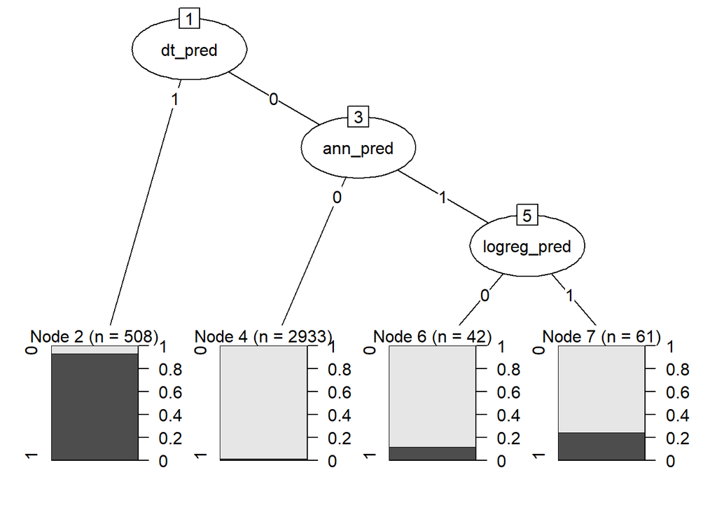

```r
plot(stacked_model)
```

```r
stacked_pred <- predict(stacked_model, credit_test1)

library(gmodels)
library(caret)

confusionMatrix(as.factor(stacked_pred), as.factor(credit_test1$credit_test.Attrition_Flag1), positive = "1")
```

```
## Confusion Matrix and Statistics
##
##           Reference
## Prediction    0    1
##          0 1208   23
##          1   48  240
##
##                Accuracy : 0.9533
##                  95% CI : (0.9414, 0.9633)
##     No Information Rate : 0.8269
##     P-Value [Acc > NIR] : < 2.2e-16
##
##                   Kappa : 0.8427
##
##  Mcnemar's Test P-Value : 0.004396
##
##             Sensitivity : 0.9125
##             Specificity : 0.9618
##          Pos Pred Value : 0.8333
##          Neg Pred Value : 0.9813
##              Prevalence : 0.1731
##          Detection Rate : 0.1580
##    Detection Prevalence : 0.1896
##       Balanced Accuracy : 0.9372
##
##        'Positive' Class : 1
##
```

## Conclusion

Below are the financial results of before and after applying our model to credit card customer applications.

Before: Accepting everyone

- Number of Retained Customers = 8,500
- Number of Attrited Customer = 1,627
- Number of Rejected Customers = 0
- Profit from One Retained Customer = $180
- Cost of One Attrited Customer = $750
- Profit from Retained Customers = $1,530,000
- Cost of Attrited Customers = $1,220,250
- Total Profit = $309,750

After: Applying our model

- Number of Retained Customers = 8,054
- Number of Attrited Customer = 153
- Number of Rejected Customers = 1,920
- Profit from One Retained Customer = $180
- Cost of One Attrited Customer = $750
- Profit from Retained Customers = $1,449,720
- Cost of Attrited Customers = $114,750
- Total Profit = $1,334,970

Note: the number of retained and attrited customers were scaled to match the same number of total customers as in the “before” scenario.

In conclusion, our model increases profits by $1,025,220, or 331%. This averages to a $101 increase in profit per potential customer. Applying this model will to the bank will simplify decision-making when looking at credit card customer applications and increase profits by decreasing the amount of credit card churn.